# Tarea1_AlejandroBarrantes

Alejandro Barrantes Castro

2023-03-22

# ==========================================================================

## ERRORES

```r
RSS <- function(Pred,Real) {
  ss <- sum((Real-Pred)^2)
  return(ss)
}

RSE<-function(Pred,Real,NumPred) {
  N<-length(Real)-NumPred-1  # <- length(Real)-(NumPred+1)
  ss<-sqrt((1/N)*RSS(Pred,Real))
  return(ss)
}

MSE <- function(Pred,Real) {
  N<-length(Real)
  ss<-(1/N)*RSS(Pred,Real)
  return(ss)
}

error.relativo <- function(Pred,Real) {
  ss<-sum(abs(Real-Pred))/sum(abs(Real))
  return(ss)
}
```

# ==========================================================================

## FUNCIONES

```r
lower <- function(data, mapping){
  p <- ggplot(data = data, mapping = mapping) +
    geom_point(size = 1,col = "dodgerblue3") +
    geom_smooth(method = lm, size = 0.4, color = "red", se = FALSE)
  return(p)
}

diag <- function(data, mapping){
  p <- ggplot(data = data, mapping = mapping) +
    geom_histogram(bins = 30, col = "black", fill = "#F8766D", aes(y=..density..)) +
    geom_density()
  return(p)
}

indices.precision <- function(real, prediccion,cantidad.variables.predictoras) {
  return(list(error.cuadratico = MSE(prediccion,real),
              raiz.error.cuadratico = RSE(prediccion,real,cantidad.variables.predictoras),
              error.relativo = error.relativo(prediccion,real),
              correlacion = as.numeric(cor(prediccion,real))))
}

plot.real.prediccion <- function(real, prediccion, modelo = "") {
  g <- ggplot(data = data.frame(Real = real, Prediccion = as.numeric(prediccion)), mapping = aes(x = Real, y = Prediccion)) +
    geom_point(size = 1, col = "dodgerblue3") +
    labs(title = paste0("Real vs Predicción", ifelse(modelo == "", "", paste(", con", modelo))),
         x = "Real",
         y = "Predicción")
  return(g)
}
```

# ==========================================================================

# Ejercicio 1

## 1.1

### Cargue la tabla de datos en R y asegurese que las variables se estan leyendo de forma correcta. ¿Es necesario recodificar variables? Seleccione la variable a predecir, y tome para entrenamiento un 80 % de la tabla de datos.

```r
setwd("~/ALEJANDRO/1er Ciclo 2023/Mineria de Datos/Tarea 2/Datos_EjemplosClase_Tarea")
datos <- read.table('DeudaCredito.csv',header=TRUE, sep=',',dec='.')

datos2<-subset(datos, select = -c(X,Estudiante,Genero,Casado,Etnicidad))

indices.training <- sample(nrow(datos2), nrow(datos2)*0.8)
datos.training <- datos2[indices.training, ]

indices.testing <- sample(nrow(datos2), nrow(datos2)*0.2)
datos.testing <- datos2[indices.testing, ]
```

### Seleccione la variable a predecir: Balance

## 1.2

### Realice un Analisis Exploratorio de los datos con todos los datos que incluya al menos:

### 1.2.1 summary(…) y str()

```r
summary(datos2)
```

```
##     Ingreso           Limite       CalifCredit       Tarjetas
##  Min.   : 10.35   Min.   :  855   Min.   : 93.0   Min.   :1.000
##  1st Qu.: 21.01   1st Qu.: 3088   1st Qu.:247.2   1st Qu.:2.000
##  Median : 33.12   Median : 4622   Median :344.0   Median :3.000
##  Mean   : 45.22   Mean   : 4736   Mean   :354.9   Mean   :2.958
##  3rd Qu.: 57.47   3rd Qu.: 5873   3rd Qu.:437.2   3rd Qu.:4.000
##  Max.   :186.63   Max.   :13913   Max.   :982.0   Max.   :9.000
##       Edad         Educacion        Balance
##  Min.   :23.00   Min.   : 5.00   Min.   :   0.00
##  1st Qu.:41.75   1st Qu.:11.00   1st Qu.:  68.75
##  Median :56.00   Median :14.00   Median : 459.50
##  Mean   :55.67   Mean   :13.45   Mean   : 520.01
##  3rd Qu.:70.00   3rd Qu.:16.00   3rd Qu.: 863.00
##  Max.   :98.00   Max.   :20.00   Max.   :1999.00
```

```r
str(datos2)
```

```
## 'data.frame':    400 obs. of  7 variables:
##  $ Ingreso    : num  14.9 106 104.6 148.9 55.9 ...
##  $ Limite     : int  3606 6645 7075 9504 4897 8047 3388 7114 3300 6819 ...
##  $ CalifCredit: int  283 483 514 681 357 569 259 512 266 491 ...
##  $ Tarjetas   : int  2 3 4 3 2 4 2 2 5 3 ...
##  $ Edad       : int  34 82 71 36 68 77 37 87 66 41 ...
##  $ Educacion  : int  11 15 11 11 16 10 12 9 13 19 ...
##  $ Balance    : int  333 903 580 964 331 1151 203 872 279 1350 ...
```

### 1.2.2 La matriz de correlaciones y alguno de sus graficos. Interprete al menos dos correlaciones.

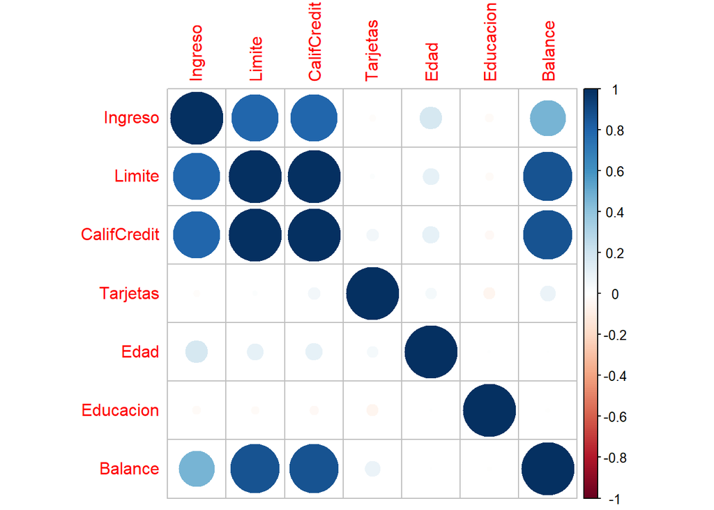

```r
matriz.correlacion<-cor(datos2)
corrplot(matriz.correlacion)
```

```r
print("-----")
```

```
## [1] "-----"
```

### 1. Limite - Balance: Se puede notar como el balance tiene una gran correlacion respecto al limite, ya que su correlacion alcanza un numero alejado de 0

### 2. CalifCredit - Balance: Se puede notar tambien como el balance tiene una gran correlacion respecto al CalifCred, ya que su correlacion alcanza un numero alejado de 0. Es decir, si una baja, la otra tambien lo hara

### 1.2.3 Atipicos

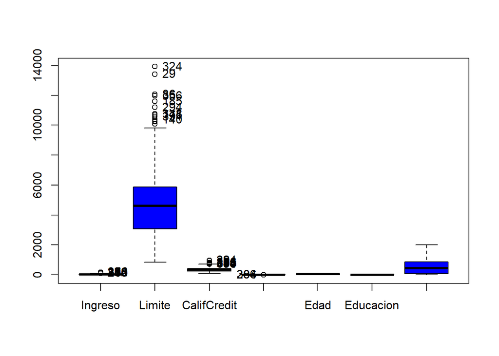

```r
atipicos<-Boxplot(datos2,data=datos2,id.method="y",col="Blue")
```

```r
atipicos
```

```
##  [1] "29"  "324" "356" "262" "276" "348" "185" "86"  "210" "340" "324" "29"
## [13] "86"  "356" "185" "294" "348" "175" "391" "140" "324" "29"  "356" "86"
## [25] "294" "185" "348" "175" "391" "194" "206" "384"
```

## 1.3 La variable numerica que parece mejor para predecir la deuda en la tarjeta de credito es la variable

#### Limite, ya que es con la que tiene mas correlacion con el balance

## 1.4 Genere un modelo de regresion lineal multiple incluyendo las todas las variables predictoras

```r
numero.predictoras <- dim(datos2)[2]
modelo.lm<-lm(Balance~.,data=datos.training)
```

### ¿Cuales coeficientes obtiene para los β?

```r
#Coeficientes para Beta
modelo.lm$coefficients
```

```
##  (Intercept)      Ingreso       Limite  CalifCredit     Tarjetas         Edad
## -422.6963778   -7.5086671    0.1620347    1.5123159   19.3044474   -1.0081853
##    Educacion
##   -1.9197125
```

## 1.5 ¿Que error se obtiene sobre la tabla de testing para el modelo de regresion lineal? Interprete las medidas de error obtenidas.

```r
prediccion <- predict(modelo.lm, datos.testing)
pre.lm <- indices.precision(datos.testing$Balance, prediccion,dim(datos.training)[2])
pre.lm
```

```
## $error.cuadratico
## [1] 30129.74
##
## $raiz.error.cuadratico
## [1] 182.9686
##
## $error.relativo
## [1] 0.2145714
##
## $correlacion
## [1] 0.9284017
```

## 1.6 Si tuviera que eliminar alguna o algunas de las variables con la esperanza de que mejore la prediccion ¿Cual o cuales de las variables eliminarıa? ¿El nuevo modelo mejora la prediccion?

```r
modelo_optimo <- step(modelo.lm, direction = "backward")
```

```
## Start:  AIC=3246.19
## Balance ~ Ingreso + Limite + CalifCredit + Tarjetas + Edad +
##     Educacion
##
##               Df Sum of Sq      RSS    AIC
## - Educacion    1     11516  7806007 3244.7
## <none>                      7794491 3246.2
## - CalifCredit  1     77013  7871504 3247.3
## - Edad         1     94416  7888907 3248.0
## - Tarjetas     1    156794  7951285 3250.6
## - Limite       1    197148  7991639 3252.2
## - Ingreso      1   8609334 16403825 3482.3
##
## Step:  AIC=3244.67
## Balance ~ Ingreso + Limite + CalifCredit + Tarjetas + Edad
##
##               Df Sum of Sq      RSS    AIC
## <none>                      7806007 3244.7
## - CalifCredit  1     81277  7887284 3246.0
## - Edad         1     94358  7900365 3246.5
## - Tarjetas     1    156637  7962644 3249.0
## - Limite       1    191563  7997570 3250.4
## - Ingreso      1   8605980 16411987 3480.5
```

```r
summary(modelo_optimo)
```

```
##
## Call:
## lm(formula = Balance ~ Ingreso + Limite + CalifCredit + Tarjetas +
##     Edad, data = datos.training)
##
## Residuals:
##     Min      1Q  Median      3Q     Max
## -216.29 -110.00  -35.38   41.61  538.40
##
## Coefficients:
##              Estimate Std. Error t value Pr(>|t|)
## (Intercept) -450.2653    44.3884 -10.144  < 2e-16 ***
## Ingreso       -7.4902     0.4026 -18.606  < 2e-16 ***
## Limite         0.1593     0.0574   2.776  0.00583 **
## CalifCredit    1.5503     0.8574   1.808  0.07154 .
## Tarjetas      19.2948     7.6867   2.510  0.01257 *
## Edad          -1.0079     0.5173  -1.948  0.05228 .
## ---
## Signif. codes:  0 '***' 0.001 '**' 0.01 '*' 0.05 '.' 0.1 ' ' 1
##
## Residual standard error: 157.7 on 314 degrees of freedom
## Multiple R-squared:  0.8882, Adjusted R-squared:  0.8864
## F-statistic:   499 on 5 and 314 DF,  p-value: < 2.2e-16
```

```r
nuevo.modelo.lm<-lm(Balance~Ingreso+CalifCredit+Edad,data=datos.training)
summary(nuevo.modelo.lm)
```

```
##
## Call:
## lm(formula = Balance ~ Ingreso + CalifCredit + Edad, data = datos.training)
##
## Residuals:
##     Min      1Q  Median      3Q     Max
## -262.69 -109.94  -32.35   57.68  554.67
##
## Coefficients:
##               Estimate Std. Error t value Pr(>|t|)
## (Intercept) -478.60746   37.24111 -12.852   <2e-16 ***
## Ingreso       -7.49798    0.40455 -18.534   <2e-16 ***
## CalifCredit    3.92943    0.09265  42.411   <2e-16 ***
## Edad          -1.07831    0.52245  -2.064   0.0398 *
## ---
## Signif. codes:  0 '***' 0.001 '**' 0.01 '*' 0.05 '.' 0.1 ' ' 1
##
## Residual standard error: 159.4 on 316 degrees of freedom
## Multiple R-squared:  0.885,  Adjusted R-squared:  0.8839
## F-statistic: 810.3 on 3 and 316 DF,  p-value: < 2.2e-16
```

```r
prediccion <- predict(nuevo.modelo.lm, datos.testing)
pre.lm <- indices.precision(datos.testing$Balance, prediccion,3)
pre.lm
```

```
## $error.cuadratico
## [1] 30551.02
##
## $raiz.error.cuadratico
## [1] 179.3292
##
## $error.relativo
## [1] 0.2151414
##
## $correlacion
## [1] 0.9279701
```

# ==========================================================================

# Ejercicio 2

## 2.1

```r
 setwd("~/ALEJANDRO/1er Ciclo 2023/Mineria de Datos/Tarea 2/Datos_EjemplosClase_Tarea")
datos <- read.table('AsientosNinno.csv',header=TRUE, sep=';',dec='.')

datos$CalidadEstant <- as.numeric(factor(datos$CalidadEstant, levels = c("Bueno","Medio","Malo"),labels=c(1,2,3))) #Recodifico CalidadEstant
datos2<-datos[,-1]# quito X
set.seed(123)
indices.training <- sample(nrow(datos2), nrow(datos2)*0.85)
datos.training <- datos2[indices.training, ]

indices.testing <- sample(nrow(datos2), nrow(datos2)*0.15)
datos.testing <- datos2[indices.testing, ]

#Variable a predecir = Ventas
```

## 2.2

### 2.2.1 summary(…).

```r
summary(datos2)
```

```
##      Ventas        PrecioCompt     Ingreso         Publicidad
##  Min.   : 0.000   Min.   : 77   Min.   : 21.00   Min.   : 0.000
##  1st Qu.: 5.390   1st Qu.:115   1st Qu.: 42.75   1st Qu.: 0.000
##  Median : 7.490   Median :125   Median : 69.00   Median : 5.000
##  Mean   : 7.496   Mean   :125   Mean   : 68.66   Mean   : 6.635
##  3rd Qu.: 9.320   3rd Qu.:135   3rd Qu.: 91.00   3rd Qu.:12.000
##  Max.   :16.270   Max.   :175   Max.   :120.00   Max.   :29.000
##    Poblacion         Precio      CalidadEstant        Edad         Educacion
##  Min.   : 10.0   Min.   : 24.0   Min.   :1.000   Min.   :25.00   Min.   :10.0
##  1st Qu.:139.0   1st Qu.:100.0   1st Qu.:2.000   1st Qu.:39.75   1st Qu.:12.0
##  Median :272.0   Median :117.0   Median :2.000   Median :54.50   Median :14.0
##  Mean   :264.8   Mean   :115.8   Mean   :2.027   Mean   :53.32   Mean   :13.9
##  3rd Qu.:398.5   3rd Qu.:131.0   3rd Qu.:2.000   3rd Qu.:66.00   3rd Qu.:16.0
##  Max.   :509.0   Max.   :191.0   Max.   :3.000   Max.   :80.00   Max.   :18.0
##      Urbano           USA
##  Min.   :0.000   Min.   :0.000
##  1st Qu.:0.000   1st Qu.:0.000
##  Median :1.000   Median :1.000
##  Mean   :0.705   Mean   :0.645
##  3rd Qu.:1.000   3rd Qu.:1.000
##  Max.   :1.000   Max.   :1.000
```

```r
str(datos2)
```

```
## 'data.frame':    400 obs. of  11 variables:
##  $ Ventas       : num  9.5 11.22 10.06 7.4 4.15 ...
##  $ PrecioCompt  : int  138 111 113 117 141 124 115 136 132 132 ...
##  $ Ingreso      : int  73 48 35 100 64 113 105 81 110 113 ...
##  $ Publicidad   : int  11 16 10 4 3 13 0 15 0 0 ...
##  $ Poblacion    : int  276 260 269 466 340 501 45 425 108 131 ...
##  $ Precio       : int  120 83 80 97 128 72 108 120 124 124 ...
##  $ CalidadEstant: num  3 1 2 2 3 3 2 1 2 2 ...
##  $ Edad         : int  42 65 59 55 38 78 71 67 76 76 ...
##  $ Educacion    : int  17 10 12 14 13 16 15 10 10 17 ...
##  $ Urbano       : int  1 1 1 1 1 0 1 1 0 0 ...
##  $ USA          : int  1 1 1 1 0 1 0 1 0 1 ...
```

### 2.2.2 La matriz de correlaciones y alguno de sus graficos.

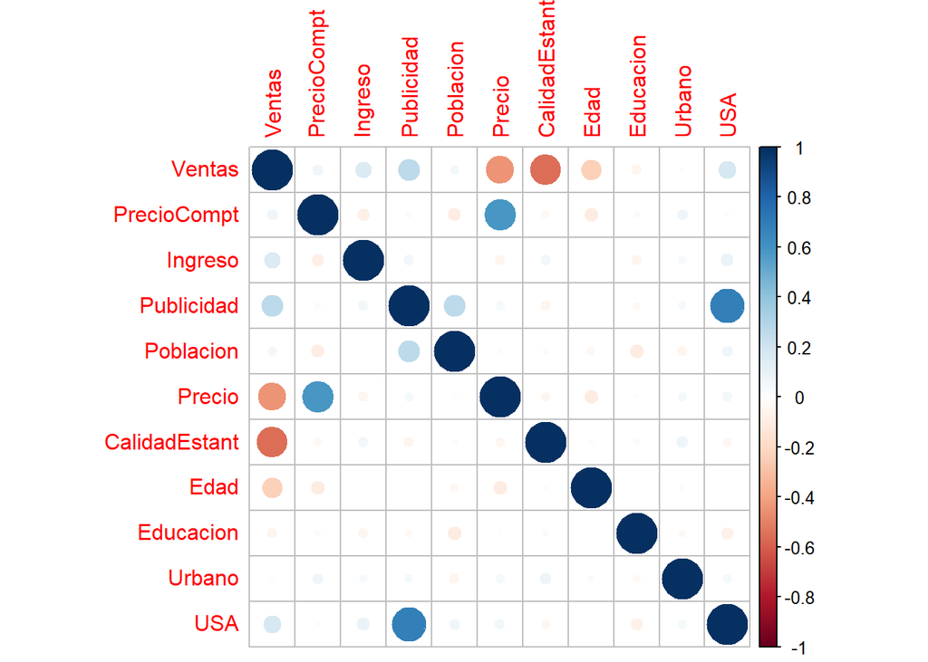

```r
matriz.correlacion<-cor(datos2)
corrplot(matriz.correlacion)
```

```r
print("-----")
```

```
## [1] "-----"
```

### Interprete al menos dos correlaciones.

#### Publicidad y USA: La publicidad aumenta si el pais es USA, es decir, existe correlacion entre ambas

#### PrecioCompt y precio: Obviamente, si el precio de la competencia varia, tambien debe variar nuestro precio, por tanto, en la matriz se observa una buena correlacion entre estas 2

### 2.2.3

### Atipicos

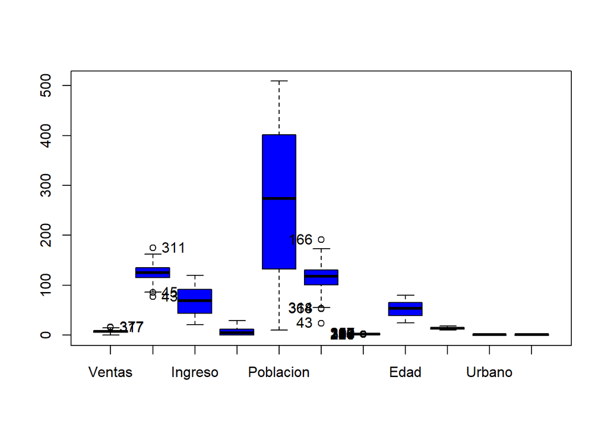

```r
atipicos<-Boxplot(datos.training,data=datos.training,id.method="y",col="Blue")
```

```r
atipicos
```

```
##  [1] "317" "377" "43"  "45"  "311" "43"  "314" "368" "166" "14"  "299" "153"
## [13] "348" "26"  "330" "364" "69"  "294" "316" "229" "399" "256" "197" "137"
## [25] "211" "81"  "359" "109" "166"
```

## 2.3 Aplique el modelo de regresion lineal multiple incluyendo todas las variables predictoras

```r
modelo.lm<-lm(Ventas~.,data=datos.training)
```

## 2.4 ¿Que error se obtiene sobre la tabla de training para el modelo generado anteriormente?

```r
prediccion <- predict(modelo.lm, datos.training)
numero.predictoras <- dim(datos.training)[2]
pre.lm <- indices.precision(datos.training$Ventas, prediccion,numero.predictoras)
pre.lm
```

```
## $error.cuadratico
## [1] 1.021762
##
## $raiz.error.cuadratico
## [1] 1.029147
##
## $error.relativo
## [1] 0.1061463
##
## $correlacion
## [1] 0.9347271
```

# ==========================================================================

# Ejercicio 3

```r
setwd("~/ALEJANDRO/1er Ciclo 2023/Mineria de Datos/Tarea 2/Datos_EjemplosClase_Tarea")
datos <- read.table('uscrime.csv',header=TRUE, sep=',',dec='.')

indices.training <- sample(nrow(datos), nrow(datos)*0.67)
datos.training <- datos[indices.training, ]

indices.testing <- sample(nrow(datos), nrow(datos)*0.33)
datos.testing <- datos[indices.testing, ]
```

## 3.1 Realice un Analisis Exploratorio de los datos con todos los datos.

```r
summary(datos)
```

```
##      state            fold          population      householdsize
##  Min.   : 1.00   Min.   : 1.000   Min.   :0.00000   Min.   :0.0000
##  1st Qu.:12.00   1st Qu.: 3.000   1st Qu.:0.01000   1st Qu.:0.3500
##  Median :34.00   Median : 5.000   Median :0.02000   Median :0.4400
##  Mean   :28.68   Mean   : 5.494   Mean   :0.05759   Mean   :0.4634
##  3rd Qu.:42.00   3rd Qu.: 8.000   3rd Qu.:0.05000   3rd Qu.:0.5400
##  Max.   :56.00   Max.   :10.000   Max.   :1.00000   Max.   :1.0000
##   racepctblack     racePctWhite     racePctAsian     racePctHisp
##  Min.   :0.0000   Min.   :0.0000   Min.   :0.0000   Min.   :0.000
##  1st Qu.:0.0200   1st Qu.:0.6300   1st Qu.:0.0400   1st Qu.:0.010
##  Median :0.0600   Median :0.8500   Median :0.0700   Median :0.040
##  Mean   :0.1796   Mean   :0.7537   Mean   :0.1537   Mean   :0.144
##  3rd Qu.:0.2300   3rd Qu.:0.9400   3rd Qu.:0.1700   3rd Qu.:0.160
##  Max.   :1.0000   Max.   :1.0000   Max.   :1.0000   Max.   :1.000
##   agePct12t21      agePct12t29      agePct16t24       agePct65up
##  Min.   :0.0000   Min.   :0.0000   Min.   :0.0000   Min.   :0.0000
##  1st Qu.:0.3400   1st Qu.:0.4100   1st Qu.:0.2500   1st Qu.:0.3000
##  Median :0.4000   Median :0.4800   Median :0.2900   Median :0.4200
##  Mean   :0.4242   Mean   :0.4939   Mean   :0.3363   Mean   :0.4232
##  3rd Qu.:0.4700   3rd Qu.:0.5400   3rd Qu.:0.3600   3rd Qu.:0.5300
##  Max.   :1.0000   Max.   :1.0000   Max.   :1.0000   Max.   :1.0000
##    numbUrban          pctUrban        medIncome         pctWWage
##  Min.   :0.00000   Min.   :0.0000   Min.   :0.0000   Min.   :0.0000
##  1st Qu.:0.00000   1st Qu.:0.0000   1st Qu.:0.2000   1st Qu.:0.4400
##  Median :0.03000   Median :1.0000   Median :0.3200   Median :0.5600
##  Mean   :0.06407   Mean   :0.6963   Mean   :0.3611   Mean   :0.5582
##  3rd Qu.:0.07000   3rd Qu.:1.0000   3rd Qu.:0.4900   3rd Qu.:0.6900
##  Max.   :1.00000   Max.   :1.0000   Max.   :1.0000   Max.   :1.0000
##   pctWFarmSelf      pctWInvInc       pctWSocSec      pctWPubAsst
##  Min.   :0.0000   Min.   :0.0000   Min.   :0.0000   Min.   :0.0000
##  1st Qu.:0.1600   1st Qu.:0.3700   1st Qu.:0.3500   1st Qu.:0.1425
##  Median :0.2300   Median :0.4800   Median :0.4750   Median :0.2600
##  Mean   :0.2916   Mean   :0.4957   Mean   :0.4711   Mean   :0.3178
##  3rd Qu.:0.3700   3rd Qu.:0.6200   3rd Qu.:0.5800   3rd Qu.:0.4400
##  Max.   :1.0000   Max.   :1.0000   Max.   :1.0000   Max.   :1.0000
##    pctWRetire       medFamInc        perCapInc       whitePerCap
##  Min.   :0.0000   Min.   :0.0000   Min.   :0.0000   Min.   :0.000
##  1st Qu.:0.3600   1st Qu.:0.2300   1st Qu.:0.2200   1st Qu.:0.240
##  Median :0.4700   Median :0.3300   Median :0.3000   Median :0.320
##  Mean   :0.4792   Mean   :0.3757   Mean   :0.3503   Mean   :0.368
```

[output cut: 127 more lines]

```
##  Max.   :1.00000   Max.   :1.0000   Max.   :1.0000   Max.   :1.0000
##  PctSameCity85    PctSameState85      LandArea          PopDens
##  Min.   :0.0000   Min.   :0.0000   Min.   :0.00000   Min.   :0.0000
##  1st Qu.:0.5200   1st Qu.:0.5600   1st Qu.:0.02000   1st Qu.:0.1000
##  Median :0.6700   Median :0.7000   Median :0.04000   Median :0.1700
##  Mean   :0.6264   Mean   :0.6515   Mean   :0.06523   Mean   :0.2329
##  3rd Qu.:0.7700   3rd Qu.:0.7900   3rd Qu.:0.07000   3rd Qu.:0.2800
##  Max.   :1.0000   Max.   :1.0000   Max.   :1.00000   Max.   :1.0000
##  PctUsePubTrans   LemasPctOfficDrugUn ViolentCrimesPerPop
##  Min.   :0.0000   Min.   :0.00000     Min.   :0.000
##  1st Qu.:0.0200   1st Qu.:0.00000     1st Qu.:0.070
##  Median :0.0700   Median :0.00000     Median :0.150
##  Mean   :0.1617   Mean   :0.09405     Mean   :0.238
##  3rd Qu.:0.1900   3rd Qu.:0.00000     3rd Qu.:0.330
##  Max.   :1.0000   Max.   :1.00000     Max.   :1.000
```

```r
str(datos)
```

```
## 'data.frame':    1994 obs. of  103 variables:
##  $ state                : int  8 53 24 34 42 6 44 6 21 29 ...
##  $ fold                 : int  1 1 1 1 1 1 1 1 1 1 ...
##  $ population           : num  0.19 0 0 0.04 0.01 0.02 0.01 0.01 0.03 0.01 ...
##  $ householdsize        : num  0.33 0.16 0.42 0.77 0.55 0.28 0.39 0.74 0.34 0.4 ...
##  $ racepctblack         : num  0.02 0.12 0.49 1 0.02 0.06 0 0.03 0.2 0.06 ...
##  $ racePctWhite         : num  0.9 0.74 0.56 0.08 0.95 0.54 0.98 0.46 0.84 0.87 ...
##  $ racePctAsian         : num  0.12 0.45 0.17 0.12 0.09 1 0.06 0.2 0.02 0.3 ...
##  $ racePctHisp          : num  0.17 0.07 0.04 0.1 0.05 0.25 0.02 1 0 0.03 ...
##  $ agePct12t21          : num  0.34 0.26 0.39 0.51 0.38 0.31 0.3 0.52 0.38 0.9 ...
##  $ agePct12t29          : num  0.47 0.59 0.47 0.5 0.38 0.48 0.37 0.55 0.45 0.82 ...
##  $ agePct16t24          : num  0.29 0.35 0.28 0.34 0.23 0.27 0.23 0.36 0.28 0.8 ...
##  $ agePct65up           : num  0.32 0.27 0.32 0.21 0.36 0.37 0.6 0.35 0.48 0.39 ...
##  $ numbUrban            : num  0.2 0.02 0 0.06 0.02 0.04 0.02 0 0.04 0.02 ...
##  $ pctUrban             : num  1 1 0 1 0.9 1 0.81 0 1 1 ...
```

[output cut: 86 more lines]

[figure not shown]

```r
matriz.correlacion<-cor(datos)
corrplot(matriz.correlacion)
```

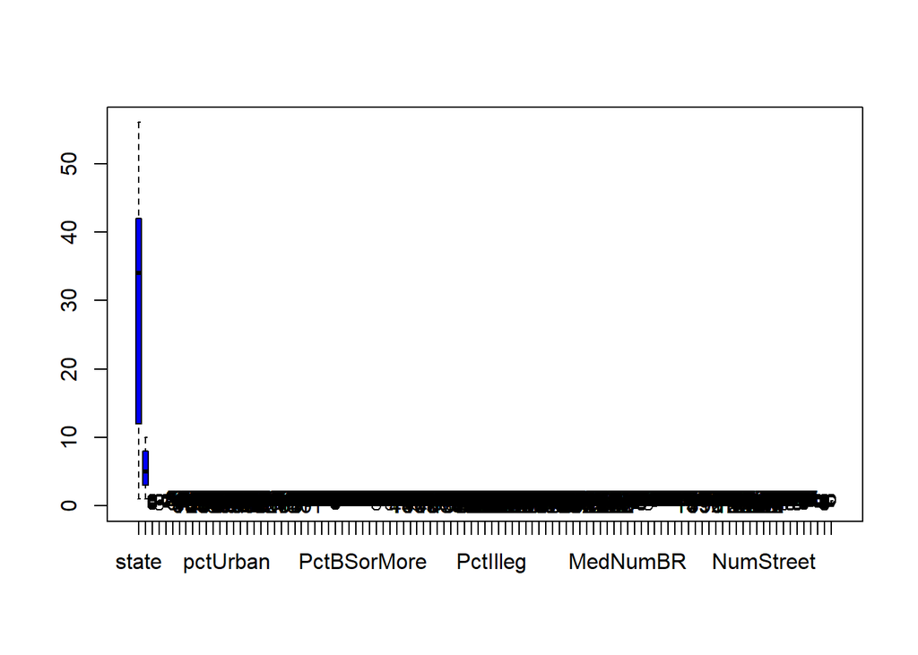

```r
atipicos<-Boxplot(datos,data=datos,id.method="y",col="Blue")
```

```r
atipicos
```

```
##   [1] "22"   "414"  "523"  "565"  "601"  "683"  "696"  "1061" "1100" "1314"
##  [11] "88"   "400"  "958"  "1071" "1354" "244"  "343"  "355"  "387"  "397"
##  [21] "463"  "472"  "647"  "669"  "673"  "4"    "43"   "117"  "158"  "198"
##  [31] "263"  "334"  "363"  "414"  "448"  "25"   "27"   "43"   "117"  "448"
##  [41] "478"  "553"  "631"  "634"  "668"  "6"    "11"   "25"   "27"   "35"
##  [51] "114"  "128"  "204"  "207"  "237"  "8"    "25"   "69"   "129"  "174"
##  [61] "244"  "260"  "299"  "318"  "326"  "958"  "1071" "1906" "400"  "1639"
##  [71] "1852" "1937" "1173" "1033" "1540" "33"   "85"   "98"   "167"  "193"
##  [81] "269"  "292"  "337"  "350"  "369"  "1071" "1033" "1639" "1937" "1852"
##  [91] "400"  "1906" "1168" "140"  "835"  "33"   "85"   "98"   "107"  "167"
## [101] "193"  "210"  "269"  "292"  "337"  "400"  "735"  "916"  "1033" "1071"
## [111] "1639" "1852" "1906" "1937" "33"   "85"   "98"   "107"  "167"  "193"
## [121] "210"  "269"  "292"  "337"  "76"   "88"   "111"  "248"  "282"  "400"
## [131] "768"  "828"  "835"  "871"  "22"   "414"  "523"  "565"  "601"  "683"
## [141] "696"  "1061" "1100" "1314" "116"  "140"  "184"  "298"  "376"  "391"
```

[output cut: 85 more lines]

## 3.2

### 3.2.1 Construya un modelo predictivo para la variable ViolentCrimesPerPop usando una Regresion Lineal Multiple con la funcion lm(…) en la Tabla de Aprendizaje, calcule Error Estandar de los Residuos para este modelo.

```r
modelo.lm<-lm(ViolentCrimesPerPop~.,data=datos.training)
summary(modelo.lm)$sigma
```

```
## [1] 0.1340859
```

### 3.2.2 Ademas calcule el Error Cuadratico Medio y el Error Relativo para la Tabla de Testing.

```r
prediccion <- predict(modelo.lm, datos.testing)
numero.predictoras <- dim(datos.testing)[2]

pre.lm <- indices.precision(datos.testing$ViolentCrimesPerPop, prediccion,numero.predictoras)
print(cat("Error cuadratico medio: ",pre.lm$error.cuadratico))
```

```
## Error cuadratico medio:  0.01614499NULL
```

```r
print(cat("Error relativo: ",pre.lm$error.relativo))
```

```
## Error relativo:  0.396406NULL
```

# ==========================================================

# OPTATIVA

```r
setwd("~/ALEJANDRO/1er Ciclo 2023/Mineria de Datos/Tarea 2/Datos_EjemplosClase_Tarea")
datos <- read.table('uscrime.csv',header=TRUE, sep=',',dec='.')


lm2 <- function(data) {
  x <- as.matrix(data[, -ncol(data)])
  y <- as.matrix(data[, ncol(data)])

  # Calcular los coeficientes de la regresión
  beta <- (solve( (t(x)%*%x) ) %*% (t(x) %*% y))

  # Crear un modelo con los coeficientes calculados
  model <- lm(y ~ x - 1, data = data.frame(cbind(x, y)))
  model$coefficients <- beta

  return(model)
}

predict2 <- function(modelo, datos_prueba) {
  predicciones <- predict(modelo, newdata = datos_prueba)
  return(predicciones)
}

modelo.lm<-lm(datos)
modelo.lm2<-lm2(datos)

summary(modelo.lm)
```

```
##
## Call:
## lm(formula = datos)
##
## Residuals:
##     Min      1Q  Median      3Q     Max
## -41.783  -6.989   0.803   7.913  31.946
##
## Coefficients:
##                         Estimate Std. Error t value Pr(>|t|)
## (Intercept)             24.52755   18.68755   1.313 0.189508
## fold                    -0.04749    0.09688  -0.490 0.624056
## population             -22.00081   36.44096  -0.604 0.546090
## householdsize           31.57586    7.91120   3.991 6.82e-05 ***
## racepctblack            -0.45908    4.71075  -0.097 0.922376
## racePctWhite            -4.64965    5.39285  -0.862 0.388693
## racePctAsian             2.75835    3.15049   0.876 0.381398
## racePctHisp             -1.37572    4.90449  -0.281 0.779123
## agePct12t21              7.95672    9.71106   0.819 0.412692
## agePct12t29            -22.22060   14.34829  -1.549 0.121631
## agePct16t24              6.15474   15.06178   0.409 0.682855
## agePct65up              -0.83989    9.49496  -0.088 0.929523
## numbUrban               41.79974   35.50465   1.177 0.239223
## pctUrban                 0.40028    1.43710   0.279 0.780633
## medIncome                9.06789   15.84070   0.572 0.567090
## pctWWage                13.66533    8.21866   1.663 0.096534 .
## pctWFarmSelf            -1.87068    1.84951  -1.011 0.311932
## pctWInvInc              21.45846    6.20727   3.457 0.000558 ***
## pctWSocSec               5.09719    9.82081   0.519 0.603808
## pctWPubAsst            -13.11521    4.22582  -3.104 0.001940 **
## pctWRetire               1.44878    3.38218   0.428 0.668440
## medFamInc               -3.75531   14.71982  -0.255 0.798659
## perCapInc               11.19233   17.30749   0.647 0.517920
## whitePerCap             -4.26236   14.00314  -0.304 0.760867
## blackPerCap             -3.32036    2.33543  -1.422 0.155268
## indianPerCap             2.03600    1.78151   1.143 0.253247
## AsianPerCap             -1.84492    1.73583  -1.063 0.287990
## OtherPerCap             -1.40621    1.71842  -0.818 0.413280
## HispPerCap              -0.58250    2.28140  -0.255 0.798499
## NumUnderPov              7.73275   12.66194   0.611 0.541466
```

[output cut: 64 more lines]

```
## PctBornSameState        15.95283    3.81388   4.183 3.01e-05 ***
## PctSameHouse85          22.45306    5.27945   4.253 2.21e-05 ***
## PctSameCity85           -8.50011    3.49415  -2.433 0.015080 *
## PctSameState85          -1.44194    3.91549  -0.368 0.712716
## LandArea               -10.36830    4.50029  -2.304 0.021335 *
## PopDens                  1.77416    2.78438   0.637 0.524083
## PctUsePubTrans           5.84772    2.12126   2.757 0.005894 **
## LemasPctOfficDrugUn     -0.51651    1.41881  -0.364 0.715866
## ViolentCrimesPerPop     -6.27250    2.10700  -2.977 0.002948 **
## ---
## Signif. codes:  0 '***' 0.001 '**' 0.01 '*' 0.05 '.' 0.1 ' ' 1
##
## Residual standard error: 12.1 on 1891 degrees of freedom
## Multiple R-squared:  0.4832, Adjusted R-squared:  0.4553
## F-statistic: 17.33 on 102 and 1891 DF,  p-value: < 2.2e-16
```

```r
summary(modelo.lm2)
```

```
##
## Call:
## lm(formula = y ~ x - 1, data = data.frame(cbind(x, y)))
##
## Residuals:
##      Min       1Q   Median       3Q      Max
## -0.51764 -0.07114 -0.01392  0.05025  0.75023
##
## Coefficients:
##          Estimate Std. Error t value Pr(>|t|)
##   [1,] -0.0007248  0.0002502  -2.896 0.003818 **
##   [2,] -0.0013920  0.0010546  -1.320 0.187008
##   [3,]  0.1253415  0.3976178   0.315 0.752621
##   [4,]  0.0028117  0.0866771   0.032 0.974125
##   [5,]  0.2313047  0.0500787   4.619 4.12e-06 ***
```

[output cut: 103 more lines]

```r
prediccion <- predict(modelo.lm, datos)
numero.predictoras <- dim(datos)[2]


pre.lm <- indices.precision(datos$ViolentCrimesPerPop, prediccion,numero.predictoras)
pre.lm
```

```
## $error.cuadratico
## [1] 940.6675
##
## $raiz.error.cuadratico
## [1] 31.50284
##
## $error.relativo
## [1] 120.1144
##
## $correlacion
## [1] -0.3041249
```

```r
prediccion2 <- predict2(modelo.lm2, datos)
numero.predictoras <- dim(datos)[2]

pre.lm2 <- indices.precision(datos$ViolentCrimesPerPop, prediccion2,numero.predictoras)
pre.lm2
```

```
## $error.cuadratico
## [1] 0.0165436
##
## $raiz.error.cuadratico
## [1] 0.1321133
##
## $error.relativo
## [1] 0.3810659
##
## $correlacion
## [1] 0.8337123
```

```r
system.time(lm(datos), gcFirst = TRUE)
```

```
##    user  system elapsed
##    0.04    0.00    0.05
```

```r
system.time(lm2(datos), gcFirst = TRUE)
```

```
##    user  system elapsed
##    0.06    0.00    0.07
```

```r
system.time(predict(modelo.lm, datos), gcFirst = TRUE)
```

```
##    user  system elapsed
##    0.02    0.00    0.01
```

```r
system.time(predict2(modelo.lm2, datos), gcFirst = TRUE)
```

```
##    user  system elapsed
##       0       0       0
```